# Homework 1

Checkout colnames in my database of customers

```
 [1] "machine_id"        "census_region"     "household_size"
 [4] "hoh_oldest_age"    "household_income"  "children"
 [7] "racial_background" "connection_speed"  "country_of_origin"
[10] "retail_index"      "spend"             "ecom_index"
```

Checkout colnames in my database of targets

```
 [1] "machine_id"        "census_region"     "household_size"
 [4] "hoh_oldest_age"    "household_income"  "children"
 [7] "racial_background" "connection_speed"  "country_of_origin"
[10] "retail_index"      "spend"             "ecom_index"
```

LEt’s see our target database

```r
target2
```

| machine_id | census_region | household_size | hoh_oldest_age | household_income | children | racial_background | connection_speed | country_of_origin | retail_index | spend | ecom_index |
| --- | --- | --- | --- | --- | --- | --- | --- | --- | --- | --- | --- |
| 1 | 2 | 4 | 1 | 1 | 1 | 1 | 1 | 1 | 0.3074444384 | 0.00 | 0.2789790528 |
| 2 | 3 | 1 | 4 | 2 | 0 | 1 | 1 | 0 | 0.4461483509 | 0.00 | 0.0486221058 |
| 3 | 3 | 6 | 5 | 7 | 1 | 1 | 1 | 0 | 0.4195633031 | 0.00 | 0.1578016789 |
| 4 | 3 | 1 | 7 | 5 | 0 | 1 | 1 | 0 | 0.2562232339 | 0.00 | 0.3353921169 |
| 5 | 4 | 1 | 6 | 1 | 0 | 1 | 1 | 0 | 0.3739167323 | 0.00 | 0.0324544202 |
| 6 | 4 | 1 | 3 | 5 | 0 | 5 | 1 | 0 | 0.1551260933 | 0.00 | 0.2015055034 |
| 7 | 1 | 2 | 3 | 6 | 1 | 1 | 1 | 0 | 0.1754811644 | 0.00 | 0.0366221335 |
| 8 | 3 | 3 | 9 | 6 | 1 | 1 | 1 | 0 | 0.1367645075 | 0.00 | 0.1290985198 |
| 9 | 1 | 5 | 5 | 7 | 1 | 1 | 1 | 0 | 0.1680283364 | 0.00 | 0.1179604744 |
| 10 | 1 | 1 | 10 | 7 | 0 | 1 | 1 | 0 | 0.4243706469 | 0.00 | 0.2826840358 |

[output cut: 990 more lines]

What would be the cost if we tried to target all our customers if we want to target them all?

```
[1] -62321.17
```

Let’s say that we want to target the people that above the 50% in the economic index

```
[1] 67 11
```

What would be the profits to target them based on ecom_index?

```r
profit_all = sum(eco_target[,"spend"]) - cost*length(eco_target[,"spend"])
profit_all
```

```
[1] 3890.89
```

Let’s say that we would like to know if an in-house algorithm can work as this accuracy.

Let’s prepare our data:

What our threshold? If we plot spend distribution

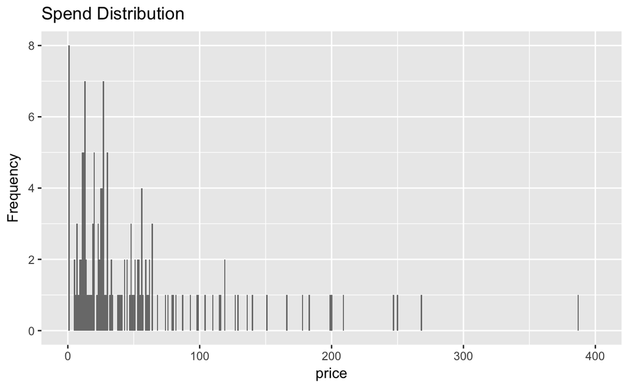

```r
cust3 = cust2[cust2$spend>0,2:11]
ggplot(cust3, aes(spend)) +
  geom_histogram(binwidth=1, alpha= .8)+
  ylab("Frequency") + xlab("price") + ggtitle("Spend Distribution") + xlim(0, 400)
```

We can see that the Median of spend is 29.9

```r
summary(cust3$spend)
```

```
   Min. 1st Qu.  Median    Mean 3rd Qu.    Max.
   0.53   14.14   29.94   97.37   61.12 6768.00
```

So we would like to match people with this the characteristics of people that spend above the meadian. So we are going to prepare these dataframes

```r
# cut the data base based on he mean $29.94 dollar treshold
cs=cust2[cust2$spend>29.94,2:10]
#create the matrix
seed=model.matrix(~census_region
                  +household_size+hoh_oldest_age
                  +household_income+children
                  +racial_background+connection_speed
                  +country_of_origin+retail_index-1, data=cs)
#cut the data
ts = target2[,2:10]
#create the matrix
targ=model.matrix(~census_region
                  +household_size+hoh_oldest_age
                  +household_income+children
                  +racial_background+connection_speed
                  +country_of_origin+retail_index-1, data=ts)
targ2=targ[,intersect(colnames(seed),colnames(targ))]
```

Let’s run our first KNNs Algorithm based on the people that spend more than the median.

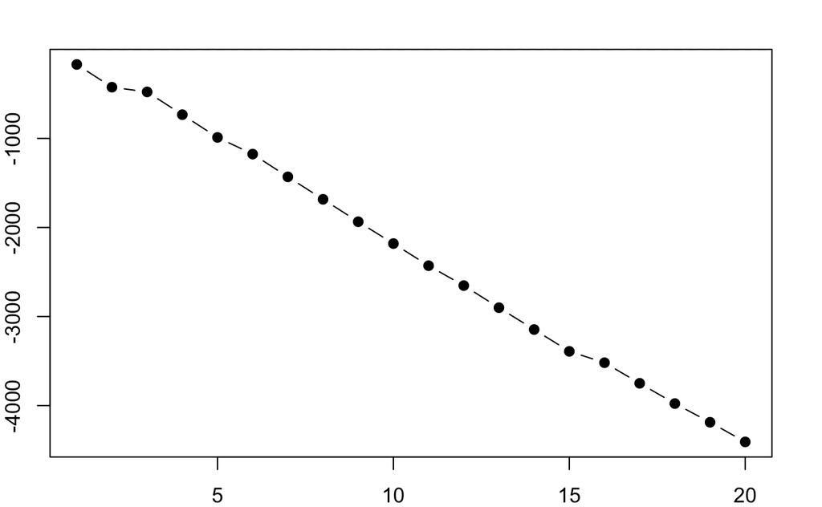

```r
profit=rep(0,20)
for(k in 1:20){
  mk = get.knnx(targ2,seed,k=k,algorithm='brute')
  matches=unique(as.vector(mk$nn.index))
  profit[k] = sum(target2[matches,"spend"])-cost*length(target2[matches,"spend"])
}
par(mar = rep(2, 4))
plot(profit,type='b',pch=19)
abline(h=2,lty=2)
```

```r
k.star = which.max(profit); k.star
```

```
[1] 1
```

```r
mk.star = get.knnx(targ2,seed,k=k.star,algorithm='brute')
matches=unique(as.vector(mk.star$nn.index))
profit.star = sum(target2[matches,"spend"])-cost*length(target2[matches,"spend"])
profit.star
```

```
[1] -169.74
```

This doesn’t look quite good. Let’s see if we can cut the dimensions to have a better approximation

```r
reg = lm(spend~census_region
         +household_size+hoh_oldest_age
         +household_income+children
         +racial_background+connection_speed
         +country_of_origin+retail_index, data=cust2)
summary(reg)
```

```
Call:
lm(formula = spend ~ census_region + household_size + hoh_oldest_age +
    household_income + children + racial_background + connection_speed +
    country_of_origin + retail_index, data = cust2)

Residuals:
   Min     1Q Median     3Q    Max
 -46.4   -6.2    0.5    3.9 6705.6

Coefficients:
                   Estimate Std. Error t value Pr(>|t|)
(Intercept)        -8.57042   25.73270  -0.333   0.7391
census_region2      7.85329    4.39541   1.787   0.0740 .
census_region3      0.51663    3.82459   0.135   0.8926
census_region4      0.11156    4.41618   0.025   0.9798
census_region88    -1.00531   13.74545  -0.073   0.9417
household_size2     0.97486    5.38280   0.181   0.8563
household_size3     0.48036    6.22485   0.077   0.9385
household_size4     2.54571    6.65062   0.383   0.7019
household_size5     0.26579    7.39144   0.036   0.9713
household_size6    18.98478    7.60959   2.495   0.0126 *
hoh_oldest_age2    28.28615   18.74864   1.509   0.1314
hoh_oldest_age3    -0.51263   18.18094  -0.028   0.9775
hoh_oldest_age4    -0.51750   18.27798  -0.028   0.9774
hoh_oldest_age5    -2.23010   18.17003  -0.123   0.9023
hoh_oldest_age6    -3.36287   18.09297  -0.186   0.8526
hoh_oldest_age7    -3.15850   18.06094  -0.175   0.8612
hoh_oldest_age8    -2.78808   18.16526  -0.153   0.8780
hoh_oldest_age9    -2.88278   18.35636  -0.157   0.8752
hoh_oldest_age10   -1.02943   18.56083  -0.055   0.9558
hoh_oldest_age11   -1.47164   18.28483  -0.080   0.9359
household_income2   0.97839    5.72553   0.171   0.8643
household_income3  -0.22001    5.69758  -0.039   0.9692
household_income4   0.20039    5.29833   0.038   0.9698
household_income5   0.40066    4.58822   0.087   0.9304
household_income6  10.40542    5.20250   2.000   0.0455 *
household_income7   1.84500    5.19587   0.355   0.7225
children1          -0.48100    5.03160  -0.096   0.9238
racial_background2 -2.73415    4.12534  -0.663   0.5075
racial_background3  0.03915   12.96580   0.003   0.9976
racial_background5 -0.47603    4.72857  -0.101   0.9198
connection_speed1   3.24875   18.07514   0.180   0.8574
country_of_origin1 -0.51932    5.23061  -0.099   0.9209
retail_index       16.66418    9.51225   1.752   0.0799 .
---
Signif. codes:  0 ‘***’ 0.001 ‘**’ 0.01 ‘*’ 0.05 ‘.’ 0.1 ‘ ’ 1

Residual standard error: 96.5 on 4967 degrees of freedom
Multiple R-squared:  0.009635,  Adjusted R-squared:  0.003255
F-statistic:  1.51 on 32 and 4967 DF,  p-value: 0.03273
```

Values of household_income== 6 and household_sie==6 are at a significance level:

```r
seed = with(cs,cbind(retail_index,household_income==6,household_size==6))
targ2 = with(target2,cbind(retail_index,household_income==6,household_size==6))
# Storage
profit2=rep(0,20)
# Loop
for(k in 1:20){
  mk = get.knnx(targ2,seed,k=k,algorithm='brute')
  matches=unique(as.vector(mk$nn.index))
  profit2[k] = sum(target2[matches,"spend"])-cost*length(target2[matches,"spend"])
}
```

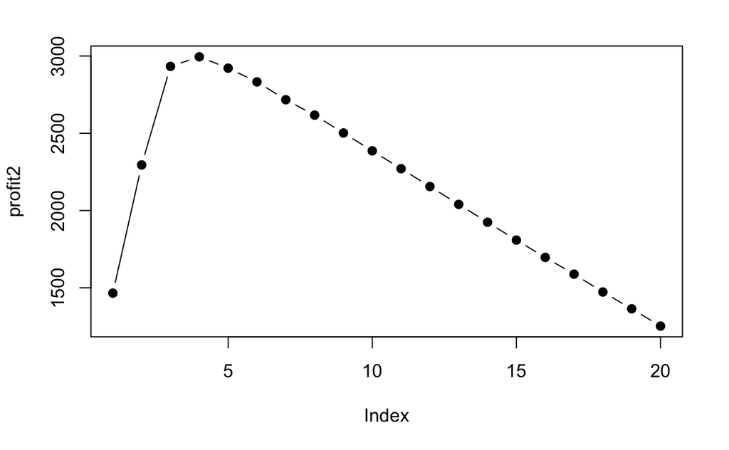

```r
# Plot
plot(profit2,type='b',pch=19)
abline(h=2,lty=2)
```

```r
# Max profits
#If our costs are .5
cost=.5
k.star = which.max(profit2); k.star
```

```
[1] 4
```

```r
mk.star = get.knnx(targ2,seed,k=k.star,algorithm='brute')
matches=unique(as.vector(mk.star$nn.index))
profit2.star = sum(target2[matches,"spend"])-cost*length(target2[matches,"spend"])
profit2.star
```

```
[1] 3537.82
```

```r
# Explore matches
# How many did we really match?
table(target2[matches,"spend"]>0)
```

```
FALSE  TRUE
  125    56
```

```r
# What percentage did we capture?
perc.captured = sum(target2[matches,"spend"])/sum(target2[,"spend"])
perc.captured
```

```
[1] 0.5514307
```